# Investigate_a_Dataset

```python
# import the tools needed

import pandas as pd
import numpy as np
import matplotlib.pyplot as plt
% matplotlib inline
```

I import the file to be analyzed and view what data is available. I decide to look at genres, popularity, and revenue as the basis of my analysis. The questions I decide to answer are:

Q1) What genres of movies are most produced per year?

Q2) Which genres are most popular per year?

Q3) Are the most profitable movies the most popular?

Q4) Which genres have been most profitable?

### Cleaning and setting up the data file for analysis

```python
# read in a data file to be used for analysis
moV = pd.read_csv('tmdb-movies.csv')
moV.head(2)
```

|  | id | imdb_id | popularity | budget | revenue | original_title | cast | homepage | director | tagline | ... | overview | runtime | genres | production_companies | release_date | vote_count | vote_average | release_year | budget_adj | revenue_adj |
| --- | --- | --- | --- | --- | --- | --- | --- | --- | --- | --- | --- | --- | --- | --- | --- | --- | --- | --- | --- | --- | --- |
| 0 | 135397 | tt0369610 | 32.985763 | 150000000 | 1513528810 | Jurassic World | Chris Pratt\|Bryce Dallas Howard\|Irrfan Khan\|Vi... | http://www.jurassicworld.com/ | Colin Trevorrow | The park is open. | ... | Twenty-two years after the events of Jurassic ... | 124 | Action\|Adventure\|Science Fiction\|Thriller | Universal Studios\|Amblin Entertainment\|Legenda... | 6/9/15 | 5562 | 6.5 | 2015 | 1.379999e+08 | 1.392446e+09 |
| 1 | 76341 | tt1392190 | 28.419936 | 150000000 | 378436354 | Mad Max: Fury Road | Tom Hardy\|Charlize Theron\|Hugh Keays-Byrne\|Nic... | http://www.madmaxmovie.com/ | George Miller | What a Lovely Day. | ... | An apocalyptic story set in the furthest reach... | 120 | Action\|Adventure\|Science Fiction\|Thriller | Village Roadshow Pictures\|Kennedy Miller Produ... | 5/13/15 | 6185 | 7.1 | 2015 | 1.379999e+08 | 3.481613e+08 |

2 rows × 21 columns

I can see that there is a significant amount of imformation that will not be pertinent to my investigation. I will remove those columns

```python
# remove columns that are not of interest
moV.drop(['tagline','keywords', 'cast', 'imdb_id', 'runtime', 'release_date', 'overview', 'vote_count', 'vote_average','homepage','budget_adj', 'revenue_adj'], axis=1, inplace=True)
moV.head()
```

|  | id | popularity | budget | revenue | original_title | director | genres | production_companies | release_year |
| --- | --- | --- | --- | --- | --- | --- | --- | --- | --- |
| 0 | 135397 | 32.985763 | 150000000 | 1513528810 | Jurassic World | Colin Trevorrow | Action\|Adventure\|Science Fiction\|Thriller | Universal Studios\|Amblin Entertainment\|Legenda... | 2015 |
| 1 | 76341 | 28.419936 | 150000000 | 378436354 | Mad Max: Fury Road | George Miller | Action\|Adventure\|Science Fiction\|Thriller | Village Roadshow Pictures\|Kennedy Miller Produ... | 2015 |
| 2 | 262500 | 13.112507 | 110000000 | 295238201 | Insurgent | Robert Schwentke | Adventure\|Science Fiction\|Thriller | Summit Entertainment\|Mandeville Films\|Red Wago... | 2015 |
| 3 | 140607 | 11.173104 | 200000000 | 2068178225 | Star Wars: The Force Awakens | J.J. Abrams | Action\|Adventure\|Science Fiction\|Fantasy | Lucasfilm\|Truenorth Productions\|Bad Robot | 2015 |
| 4 | 168259 | 9.335014 | 190000000 | 1506249360 | Furious 7 | James Wan | Action\|Crime\|Thriller | Universal Pictures\|Original Film\|Media Rights ... | 2015 |

Inspection of the head doesn't reveal Na's however, I will assume there are some. I will remove any rows containing Na's in the genres column since that is the basis for my analysis.

```python
moV = moV.dropna(axis=0, subset=['genres'])
sum(moV['genres']== 'Na')
```

```
0
```

I will fill any other Na's with 'unknown'

```python
moV.fillna('unknown', inplace=True)
```

Initial inspection revealed there are two columns of interest that contain multiple datum that I need to split. I will keep only the first datum assuming it is the most signicant

```python
# split columns with multiple values keeping only the first datum
split_columns = ['genres', 'production_companies']
for c in split_columns:
    moV[c] = moV[c].apply(lambda x: x.split('|')[0])
moV.head()
```

|  | id | popularity | budget | revenue | original_title | director | genres | production_companies | release_year |
| --- | --- | --- | --- | --- | --- | --- | --- | --- | --- |
| 0 | 135397 | 32.985763 | 150000000 | 1513528810 | Jurassic World | Colin Trevorrow | Action | Universal Studios | 2015 |
| 1 | 76341 | 28.419936 | 150000000 | 378436354 | Mad Max: Fury Road | George Miller | Action | Village Roadshow Pictures | 2015 |
| 2 | 262500 | 13.112507 | 110000000 | 295238201 | Insurgent | Robert Schwentke | Adventure | Summit Entertainment | 2015 |
| 3 | 140607 | 11.173104 | 200000000 | 2068178225 | Star Wars: The Force Awakens | J.J. Abrams | Action | Lucasfilm | 2015 |
| 4 | 168259 | 9.335014 | 190000000 | 1506249360 | Furious 7 | James Wan | Action | Universal Pictures | 2015 |

I am interested in profits so I will add a column that contains the difference between the 'revenue' and 'budget' columns

```python
profit=moV['revenue']-moV['budget']
moV = pd.concat([moV,profit],axis=1,  sort=False)
moV = moV.rename(columns={moV.columns[-1]: 'profit'})
moV.head()
```

|  | id | popularity | budget | revenue | original_title | director | genres | production_companies | release_year | profit |
| --- | --- | --- | --- | --- | --- | --- | --- | --- | --- | --- |
| 0 | 135397 | 32.985763 | 150000000 | 1513528810 | Jurassic World | Colin Trevorrow | Action | Universal Studios | 2015 | 1363528810 |
| 1 | 76341 | 28.419936 | 150000000 | 378436354 | Mad Max: Fury Road | George Miller | Action | Village Roadshow Pictures | 2015 | 228436354 |
| 2 | 262500 | 13.112507 | 110000000 | 295238201 | Insurgent | Robert Schwentke | Adventure | Summit Entertainment | 2015 | 185238201 |
| 3 | 140607 | 11.173104 | 200000000 | 2068178225 | Star Wars: The Force Awakens | J.J. Abrams | Action | Lucasfilm | 2015 | 1868178225 |
| 4 | 168259 | 9.335014 | 190000000 | 1506249360 | Furious 7 | James Wan | Action | Universal Pictures | 2015 | 1316249360 |

### At this point I can start to manipulate the data for viewing

First I will group years 2010-2015 for use later

```python
moV2010_2015 = moV[moV['release_year'] >= 2010]
```

I created a function to rename columns that have the same name so I can then properly name them

```python
def column_rename_multiple_same(file,col_name):
    cols = []
    count = 1
    for column in file.columns:
        if column == col_name:
            cols.append(col_name + f'{count}')
            count+=1
            continue
        cols.append(column)

    file.columns = cols
```

I also created a function to split the year from the main file

```python
def split_year(file, year):
        m = file[file['release_year'] == year]
        return m
```

Next I will be looking at each year from 2010-2015 seperately so I will split them now

```python
movies10 = split_year(moV, 2010)
movies11 = split_year(moV, 2011)
movies12 = split_year(moV, 2012)
movies13 = split_year(moV, 2013)
movies14 = split_year(moV, 2014)
movies15 = split_year(moV, 2015)
```

I count each genre per year

```python
moV10 = movies10.groupby('genres').count()['id']
moV11 = movies11.groupby('genres').count()['id']
moV12 = movies12.groupby('genres').count()['id']
moV13 = movies13.groupby('genres').count()['id']
moV14 = movies14.groupby('genres').count()['id']
moV15 = movies15.groupby('genres').count()['id']
```

I group this information together in one file for the ease of plotting it. I fill Na's and check that it is what I expected

```python
movies = pd.concat([moV10,moV11,moV12,moV13,moV14,moV15],axis=1, sort=False)
movies.fillna(0,inplace=True)  # I know there are Nan values that will cause problems
movies.head()
```

|  | id | id | id | id | id | id |
| --- | --- | --- | --- | --- | --- | --- |
| Action | 66.0 | 67.0 | 67.0 | 87.0 | 65.0 | 59.0 |
| Adventure | 19.0 | 31.0 | 20.0 | 17.0 | 29.0 | 20.0 |
| Animation | 34.0 | 28.0 | 26.0 | 28.0 | 15.0 | 13.0 |
| Comedy | 97.0 | 100.0 | 110.0 | 115.0 | 102.0 | 78.0 |
| Crime | 18.0 | 16.0 | 13.0 | 17.0 | 18.0 | 22.0 |

All column names are the same so I need to address that. First I add a count to their name so each are unique, then change it to the proper year and verify changes.

```python
column_rename_multiple_same(movies,'id')

movies.rename(columns={ 'id1':'2010','id2': "2011" , 'id3': "2012", 'id4':'2013', 'id5': '2014', 'id6':'2015'}, inplace=True)
movies.head(2)
```

|  | 2010 | 2011 | 2012 | 2013 | 2014 | 2015 |
| --- | --- | --- | --- | --- | --- | --- |
| Action | 66.0 | 67.0 | 67.0 | 87.0 | 65.0 | 59.0 |
| Adventure | 19.0 | 31.0 | 20.0 | 17.0 | 29.0 | 20.0 |

I want a list of the genres to use as labels

```python
names = moV['genres'].unique()
name =names.tolist()
name.sort()
```

My first plot will show the amount of movies produced per year by genre. This answers my first question

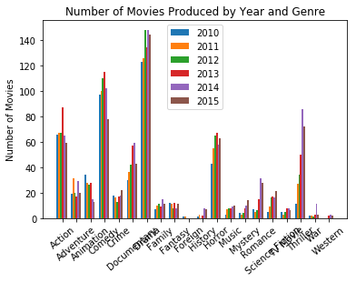

```python
width = 0.12
index = np.arange(len(movies['2010']))

plt.bar(index,movies['2010'],width, label='2010')
plt.bar(index+ width, movies['2011'],width, label='2011')
plt.bar(index+(2*width), movies['2012'],width, label='2012')
plt.bar(index+(3*width), movies['2013'],width, label='2013')
plt.bar(index+(4*width), movies['2014'],width, label='2014')
plt.bar(index+(5*width), movies['2015'],width, label='2015')
plt.ylabel('Number of Movies')
plt.title('Number of Movies Produced by Year and Genre')
plt.xticks( index+(3*width),name, rotation=40)
plt.legend()
plt.show()
```

### Looks like Drama is the most produced genre

Next I will look at the popularity per genre per year. I will split the data , then combine them into one series and take care of any Na's

```python
moV10_pop = movies10.groupby('genres')['popularity'].mean()
moV11_pop = movies11.groupby('genres')['popularity'].mean()
moV12_pop = movies12.groupby('genres')['popularity'].mean()
moV13_pop = movies13.groupby('genres')['popularity'].mean()
moV14_pop = movies14.groupby('genres')['popularity'].mean()
moV15_pop = movies15.groupby('genres')['popularity'].mean()
```

```python
movies_pop = pd.concat([moV10_pop,moV11_pop,moV12_pop,moV13_pop,moV14_pop,moV15_pop],axis=1, sort=False)
movies_pop.fillna(0,inplace=True)  # I know there are Nan values that will cause problems
movies_pop.head()
```

|  | popularity | popularity | popularity | popularity | popularity | popularity |
| --- | --- | --- | --- | --- | --- | --- |
| Action | 1.025166 | 1.012548 | 1.056954 | 0.969048 | 1.954755 | 2.881386 |
| Adventure | 1.600994 | 1.216805 | 1.105026 | 0.935867 | 2.363833 | 2.149264 |
| Animation | 0.595166 | 0.885230 | 0.885061 | 1.065841 | 0.815055 | 0.606748 |
| Comedy | 0.547223 | 0.671555 | 0.468286 | 0.544254 | 0.722765 | 0.923022 |
| Crime | 0.546363 | 0.541410 | 0.787069 | 0.835374 | 1.212061 | 1.824494 |

Again, I need to change the column names so I'll use the function to create unique names and then correct them.

```python
column_rename_multiple_same(movies_pop,'popularity')
movies_pop.rename(columns={ 'popularity1':'2010','popularity2': "2011",'popularity3':'2012', 'popularity4':'2013', 'popularity5':'2014', 'popularity6':'2015',}, inplace=True)
```

Plot of popularity of genre per year. Looking at my second question

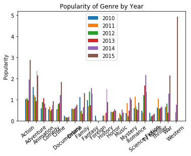

```python
width = 0.12
index = np.arange(len(movies_pop))

plt.bar(index,movies_pop['2010'],width, label='2010')
plt.bar(index+ width, movies_pop['2011'],width, label='2011')
plt.bar(index+(2*width), movies_pop['2012'],width, label='2012')
plt.bar(index+(3*width), movies_pop['2013'],width, label='2013')
plt.bar(index+(4*width), movies_pop['2014'],width, label='2014')
plt.bar(index+(5*width), movies_pop['2015'],width, label='2015')
plt.ylabel('Popularity')
plt.title('Popularity of Genre by Year')
plt.xticks( index+(3*width),name, rotation=40)
plt.legend()
plt.show()
```

### Looks like Westerns were very popular in 2015. Other then that, Action, Adventure, and Romance seem to be among the most popular. They are not clear winners probably due to some highly loved movies in other genres. Looks like a movie is chosen more than a general genre.

Now I'll look at the three most popular movies per year. First I identify them, then collect them into one series, and verify. There should be a total of 18, 3 per year.

```python
look_at_popularity_10 = movies10.nlargest(3,['popularity'])
look_at_popularity_11 = movies11.nlargest(3,['popularity'])
look_at_popularity_12 = movies12.nlargest(3,['popularity'])
look_at_popularity_13 = movies13.nlargest(3,['popularity'])
look_at_popularity_14 = movies14.nlargest(3,['popularity'])
look_at_popularity_15 = movies15.nlargest(3,['popularity'])
TopPopular = pd.concat([look_at_popularity_10,look_at_popularity_11,look_at_popularity_12,look_at_popularity_13,look_at_popularity_14,look_at_popularity_15],axis=0, sort=False)
TopPopular.head()
```

[output not shown]

I want to answer question 3: Are the most profitable movies the most popular so I make a plot of popularity vs. profit. If they were correlated in this manner, we would see the plot trending in the fashion of a positive sloped line.

```python
plt.scatter(x=TopPopular['popularity'], y=TopPopular['profit'])
plt.xlabel('popularity')
plt.ylabel('profit')
```

[output not shown]

Now I would like to look at the genres of the most popular movies. I take the top 3 most popular movies per year, collect them in one file.

```python
TP10 = look_at_popularity_10.genres
TP11 = look_at_popularity_11.genres
TP12 = look_at_popularity_12.genres
TP13 = look_at_popularity_13.genres
TP14 = look_at_popularity_14.genres
TP15 = look_at_popularity_15.genres
Top3Genres = pd.concat([TP10,TP11,TP12,TP13,TP14,TP15],axis=0, sort=False)
```

Display the top 3 genres from 2010-2015 as a pie chart to see which genres are the most popular

```python
labels = Top3Genres.loc[:1].unique().tolist()
count = Top3Genres.loc[:2].value_counts()
fig1, ax1 = plt.subplots()
ax1.pie(count, labels=labels, autopct='%1.1f%%')
ax1.axis('equal')
plt.title('Top 3 Popular Genres per Year in 2010-2015')
plt.show()
```

[output not shown]

Now I will look at the profit margin by taking the top three profitable movies per year and combine into one file. This will help answer question 4.

```python
TPP10 = movies10.nlargest(3,['profit'])
TPP11 = movies11.nlargest(3,['profit'])
TPP12 = movies12.nlargest(3,['profit'])
TPP13 = movies13.nlargest(3,['profit'])
TPP14 = movies14.nlargest(3,['profit'])
TPP15 = movies15.nlargest(3,['profit'])
TopProfitable = pd.concat([TPP10,TPP11,TPP12,TPP13,TPP14,TPP15],axis=0, sort=False)
TopProfitable['genres'].unique()
```

[output not shown]

I will put each genre into it's own file for plotting purposes

```python
TTPP = TopProfitable[['genres', 'profit']]
TTPP
TP_act =TTPP[TTPP['genres']=='Action']
TP_fam =TTPP[TTPP['genres']=='Family']
TP_adv =TTPP[TTPP['genres']=='Adventure']
TP_ani =TTPP[TTPP['genres']=='Animation']
TP_sci =TTPP[TTPP['genres']=='Science Fiction']
```

I want to look at the statistics of the profits of the most profitable genres. To do this, I get the statistics, combine them into one file, rename the columns so they are unique and then rename them again with the proper genre.

```python
A = TP_act.describe()
B = TP_adv.describe()
C = TP_ani.describe()
D = TP_fam.describe()
E = TP_sci.describe()
profit_stats = pd.concat([A,B,C,D,E],axis=1, sort=False)
column_rename_multiple_same(profit_stats,'profit')
profit_stats.rename(columns={ 'profit1':'action','profit2': "adventure" , 'profit3': "animation", 'profit4':'family', 'profit5': 'scienceFiction'}, inplace=True)
profit_stats
```

[output not shown]

I want to look at this visually as well so I plot a box plot of the same data

```python
data = [TP_act['profit'], TP_adv['profit'], TP_ani['profit'],TP_fam['profit'], TP_sci['profit']]

fig = plt.figure(figsize =(10, 9))
ax = fig.add_axes([0, 0, 1, 1])
plt.xlabel('genres')
ax.boxplot(data)
ax.set_xticklabels(['action', 'adventure', 'animation', 'family', 'science fiction'] )
plt.show()
```

[output not shown]

Plot a pie chart of the top 3 profitable movies per year by genre which helps to answer question 3.

```python
labels = TopProfitable.iloc[:,6].unique().tolist()
TPGenres = TopProfitable.iloc[:,6].value_counts()
fig1, ax1 = plt.subplots()
ax1.pie(TPGenres, labels=labels, autopct='%1.1f%%')
ax1.axis('equal')
plt.title('Genres of the Top 3 Most Profitable Movies per Year in 2010-2015')
plt.show()
```

[output not shown]

### The following analysis is my curosity of which movies are the most popular and profitable...By name

MOST PROFITABLE LIST OF MOVIES 2010-2015

```python
TopProfitable['original_title']
```

[output not shown]

MOST POPULAR LIST OF MOVIES 2010-2015

```python
TopPopular['original_title']
```

[output not shown]

What movies are both Popular and Profitable

```python
set(TopPopular['original_title']) & set(TopProfitable['original_title'])
```

[output not shown]

What are the genres of the movies that are both Popular and Profitable

```python
set(TopPopular['genres']) & set(TopProfitable['genres'])
```

[output not shown]

## Conclusions

While Drama movies are the most produced, they do not hold the most popoular spot or even close to it and did not make the list of top profitable genres. The data studied here does not suggest that the most produced genre or popularity with a particular genre leads to increased revenue, there is no correlation.

### Limitation

There are several limitations to this study, the biggest being the group polled. How large of a population was polled? What was the age bracket polled? Had everyone polled seen the same movies? Was each movie rated by the same amount of people? Did most people favor action over drama, etc? All of these factors may have influence on the outcome of the analysis. Other limitations could be the movies or lack of movies on the list. The language the movie is seen in could change perception. Or the fact that I took only the first genre when multiple were listed. All of these issues could have an impact on the analysis.

```python
from subprocess import call
call(['python', '-m', 'nbconvert', 'Investigate_a_Dataset.ipynb'])
```

## OPTIONAL: Question for the reviewer

I would have liked to make each genre a different color in my scatter plot. I couldn't find documentation to help. I'd appreciate any suggestions.